# Аналитика для интернет-магазина

Цель проекта - анализ воронки событий и результатов А/В теста.

1. Подготовка и проверка данных

2. Воронка событий

3. Результаты А/В теста

```python
import pandas as pd
from scipy import stats as st
import math as mth
import numpy as np
import matplotlib.pyplot as plt
from plotly import graph_objects as go

plt.style.use('ggplot')
```

## Подготовка и проверка данных

```python
# импорт данных
df = pd.read_csv('./logs_exp.csv', sep =',', index_col=0)
df.head()
```

|  | EventName | DeviceIDHash | EventTimestamp | ExpId |
| --- | --- | --- | --- | --- |
| 0 | MainScreenAppear | 4575588528974610257 | 1564029816 | 246 |
| 1 | MainScreenAppear | 7416695313311560658 | 1564053102 | 246 |
| 2 | PaymentScreenSuccessful | 3518123091307005509 | 1564054127 | 248 |
| 3 | CartScreenAppear | 3518123091307005509 | 1564054127 | 248 |
| 4 | PaymentScreenSuccessful | 6217807653094995999 | 1564055322 | 248 |

```python
df.info()
```

```
<class 'pandas.core.frame.DataFrame'>
Int64Index: 244126 entries, 0 to 244125
Data columns (total 4 columns):
 #   Column          Non-Null Count   Dtype
---  ------          --------------   -----
 0   EventName       244126 non-null  object
 1   DeviceIDHash    244126 non-null  int64
 2   EventTimestamp  244126 non-null  int64
 3   ExpId           244126 non-null  int64
dtypes: int64(3), object(1)
memory usage: 9.3+ MB
```

```python
# переименование колонок
df.set_axis(['event', 'user_id', 'datetime', 'group'], axis=1, inplace=True)
```

```python
# приведение колонки со временем к нужному типу, выделение столбца с датой
df['datetime'] = pd.to_datetime(df['datetime'],unit='s')
df['date'] = df['datetime'].astype('datetime64[D]')
```

```python
# удаление дубликатов
df.drop_duplicates(inplace = True)
# проверка
df[df.duplicated(keep=False)]
```

|  | event | user_id | datetime | group | date |
| --- | --- | --- | --- | --- | --- |

```python
# проверяем, по сколько пользователей в каждой группе
df.groupby('group')['user_id'].nunique()
```

```
group
246    2489
247    2520
248    2542
Name: user_id, dtype: int64
```

### Основные параметры лога

```python
print('Всего событий в логе -', len(df))
print('Всего пользователей в логе -', df['user_id'].nunique())
print('В среднем на пользователя приходится {0:.2f} событий'.format(len(df)/df['user_id'].nunique()))
```

```
Всего событий в логе - 243713
Всего пользователей в логе - 7551
В среднем на пользователя приходится 32.28 событий
```

### Время данных в логе

```python
print('Минимальная дата -', df['date'].min())
print('Максимальная дата -', df['date'].max())
```

```
Минимальная дата - 2019-07-25 00:00:00
Максимальная дата - 2019-08-07 00:00:00
```

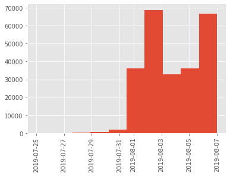

```python
# гистограмма по дате
df['date'].hist()
plt.xticks(rotation=90)
plt.show()
```

```python
# очевидно, полные данные есть только с 1 августа. Посмотрим на их долю
print('Доля событий с даты 2019-08-01 составляет {0:.02%}'.format(len(df[df['date']>='2019-08-01'])/len(df)))
```

```
Доля событий с даты 2019-08-01 составляет 98.84%
```

```python
# отбрасываем старые данные
logs_correct = df[df['date']>='2019-08-01']

print('Всего',len(df)-len(logs_correct),'событий потеряли при отбрасывании старых данных')
print('Всего',df['user_id'].nunique()-logs_correct['user_id'].nunique(),
      'пользователей потеряли при отбрасывании старых данных')
```

```
Всего 2826 событий потеряли при отбрасывании старых данных
Всего 17 пользователей потеряли при отбрасывании старых данных
```

## Воронка событий

```python
# какие события есть в логах и как часто они встречаются
logs_correct.groupby('event')['user_id'].count().sort_values(ascending = False)
```

```
event
MainScreenAppear           117328
OffersScreenAppear          46333
CartScreenAppear            42303
PaymentScreenSuccessful     33918
Tutorial                     1005
Name: user_id, dtype: int64
```

```python
# сколько пользователей хотя бы раз совершали событие
funnel = pd.DataFrame()
funnel['unique'] = logs_correct.groupby('event')['user_id'].nunique().sort_values(ascending = False)
# и какая доля пользователей
funnel['share'] = funnel['unique']/logs_correct['user_id'].nunique()
funnel.reset_index(inplace = True)
funnel['share'] = funnel['share'].map(lambda n: '{:,.2%}'.format(n))
funnel
```

|  | event | unique | share |
| --- | --- | --- | --- |
| 0 | MainScreenAppear | 7419 | 98.47% |
| 1 | OffersScreenAppear | 4593 | 60.96% |
| 2 | CartScreenAppear | 3734 | 49.56% |
| 3 | PaymentScreenSuccessful | 3539 | 46.97% |
| 4 | Tutorial | 840 | 11.15% |

Судя по всему, у нас есть четыре основных события в приложении, и идут они в таком порядке:

- главный экран (MainScreenAppear),
- просмотр страниц с товарами (OffersScreenAppear),
- просмотр корзины (CartScreenAppear),
- успешная оплата заказа (PaymentScreenSuccessful).

Есть еще Tutorial, это должна быть страница с хелпом, доля пользователей на ней незначительна, в воронку ее включать не нужно, т.к. она не принимает участия в общей последовательности событий.

```python
# уберем Tutorial из последовательности событий
funnel = funnel[funnel['event']!='Tutorial']

# воронка событий с процентами
fig = go.Figure(go.Funnel(
    x=funnel['unique'],
    y=funnel['event']
    ))
fig.show()
```

[interactive chart not shown]

Эта воронка без учета последовательности событий показывает скорее количество пользователей, которые совершают то или иное событие. Судя по этой воронке, самое значительно количество пользователей (38%) теряется на этапе OffersScreenAppear. До дальнейших этапов доходит почти то же число, и в конечном итоге на этапе успешного платежа оказывается 47,7% пользователей. Это высокий процент, но лучше посмотреть еще на воронку с учетом последовательности событий, чтобы знать, что происходит с пользователями, проходящими именно этот последовательный путь.

```python
# сводная таблица для продуктовой воронки с учетом последовательности событий
users_events = logs_correct.pivot_table(index='user_id',
        columns='event', values='datetime',aggfunc='min')

# условия для воронки с учетом последовательности событий
step_1 = ~users_events['MainScreenAppear'].isna()
step_2 = step_1 & (users_events['OffersScreenAppear'] > users_events['MainScreenAppear'])
step_3 = step_2 & (users_events['CartScreenAppear'] > users_events['OffersScreenAppear'])
step_4 = step_3 & (users_events['PaymentScreenSuccessful'] > users_events['CartScreenAppear'])

# результаты воронки с учетом последовательности событий
n_mainscreen = users_events[step_1].shape[0]
n_offerscreen = users_events[step_2].shape[0]
n_cart = users_events[step_3].shape[0]
n_payment = users_events[step_4].shape[0]

# график воронки с учетом последовательности событий
fig = go.Figure(go.Funnel(
    y=funnel['event'],x = [n_mainscreen, n_offerscreen, n_cart, n_payment]
    ))
fig.show()
```

[interactive chart not shown]

Результаты совсем другие. При последовательном переходе от события к событию на конечном этапе оказывается только 6% от изначального числа, что говорит о том, что путь до покупки может иметь самую разную конфигурацию, не только эту.

## Результаты А/В теста

Рассчитаем количество пользователей в каждой группе, сразу сложив две контрольные (она будет под номером 250), и посчитаем для каждой группы количество пользователей, совершавших то или иное событие, и их долю от общего числа пользователей.

```python
# проверяем, по сколько пользователей в каждой группе
users_per_group = logs_correct.groupby('group')['user_id'].nunique()

#объединенная контрольная группа
users_per_group[250]=users_per_group[246]+users_per_group[247]

users_per_group
```

```
group
246    2484
247    2513
248    2537
250    4997
Name: user_id, dtype: int64
```

```python
# сколько всего пользователей совершили то или иное событие в группе
events_groups = logs_correct.pivot_table(index = 'event', columns = 'group', values = 'user_id', aggfunc = 'nunique')\
.sort_values(by = 246, ascending = False)\
.reset_index()

#объединенная контрольная группа
events_groups[250]=events_groups[246]+events_groups[247]

# доля пользователей, совершивших то или иное событие, от общего числа пользователей в группе
for group in [246, 247, 248, 250]:
    events_groups["share_{}".format(group)] = events_groups[group] / users_per_group.at[group]

events_groups
```

| group | event | 246 | 247 | 248 | 250 | share_246 | share_247 | share_248 | share_250 |
| --- | --- | --- | --- | --- | --- | --- | --- | --- | --- |
| 0 | MainScreenAppear | 2450 | 2476 | 2493 | 4926 | 0.986312 | 0.985277 | 0.982657 | 0.985791 |
| 1 | OffersScreenAppear | 1542 | 1520 | 1531 | 3062 | 0.620773 | 0.604855 | 0.603469 | 0.612768 |
| 2 | CartScreenAppear | 1266 | 1238 | 1230 | 2504 | 0.509662 | 0.492638 | 0.484825 | 0.501101 |
| 3 | PaymentScreenSuccessful | 1200 | 1158 | 1181 | 2358 | 0.483092 | 0.460804 | 0.465510 | 0.471883 |
| 4 | Tutorial | 278 | 283 | 279 | 561 | 0.111916 | 0.112614 | 0.109972 | 0.112267 |

Самый простой способ найти отличия между группами - провести z-test. Обернем его в функцию, чтобы искать различия для каждого события между двумя любыми группами автоматически.

**Н0:** группы не различаются, **H1:** между группами есть различия.

```python
def z_test(event_name, group_1, group_2, alpha):
    successes = events_groups[events_groups["event"] == event_name].reset_index()

    # пропорция успехов в первой группе:
    p1 = successes.at[0, "share_{}".format(group_1)]

    # пропорция успехов во второй группе:
    p2 = successes.at[0, "share_{}".format(group_2)]

    # пропорция успехов в комбинированном датасете:
    p_combined = (successes.at[0, group_1] + successes.at[0, group_2]) / (users_per_group.at[group_1] + users_per_group.at[group_2])

    # разница пропорций в датасетах
    difference = p1 - p2

    # считаем статистику в ст.отклонениях стандартного нормального распределения
    z_value = difference / mth.sqrt(p_combined * (1 - p_combined) * (1/users_per_group.at[group_1] + 1/users_per_group.at[group_2]))

    # задаем стандартное нормальное распределение (среднее 0, ст.отклонение 1)
    distr = st.norm(0, 1)

    p_value = (1 - distr.cdf(abs(z_value))) * 2

    print('p-значение: ', p_value)

    if (p_value < alpha):
        print("Отвергаем нулевую гипотезу: между долями есть значимая разница")
        return False
    else:
        print("Не получилось отвергнуть нулевую гипотезу, нет оснований считать доли разными")
        return True
```

```python
# А/А тест, сравнение двух контрольных групп
for event in pd.Series.tolist(events_groups['event']):
    print(event)
    z_test(event, 246, 247, 0.05)
```

```
MainScreenAppear
p-значение:  0.7570597232046099
Не получилось отвергнуть нулевую гипотезу, нет оснований считать доли разными
OffersScreenAppear
p-значение:  0.2480954578522181
Не получилось отвергнуть нулевую гипотезу, нет оснований считать доли разными
CartScreenAppear
p-значение:  0.22883372237997213
Не получилось отвергнуть нулевую гипотезу, нет оснований считать доли разными
PaymentScreenSuccessful
p-значение:  0.11456679313141849
Не получилось отвергнуть нулевую гипотезу, нет оснований считать доли разными
Tutorial
p-значение:  0.9376996189257114
Не получилось отвергнуть нулевую гипотезу, нет оснований считать доли разными
```

Сравнение двых контрольных групп (246 и 247) показывает, что различий между группами, скорее всего, нет, т.е. разбиение на группы работает корректно.

Теперь сравним экспериментальную группу с каждой группой в отдельности и с объединенной группой.

```python
# А/B тест 1
for event in pd.Series.tolist(events_groups['event']):
    print(event)
    z_test(event, 248, 246, 0.05)
```

```
MainScreenAppear
p-значение:  0.2949721933554552
Не получилось отвергнуть нулевую гипотезу, нет оснований считать доли разными
OffersScreenAppear
p-значение:  0.20836205402738917
Не получилось отвергнуть нулевую гипотезу, нет оснований считать доли разными
CartScreenAppear
p-значение:  0.07842923237520116
Не получилось отвергнуть нулевую гипотезу, нет оснований считать доли разными
PaymentScreenSuccessful
p-значение:  0.2122553275697796
Не получилось отвергнуть нулевую гипотезу, нет оснований считать доли разными
Tutorial
p-значение:  0.8264294010087645
Не получилось отвергнуть нулевую гипотезу, нет оснований считать доли разными
```

```python
# А/B тест 2
for event in pd.Series.tolist(events_groups['event']):
    print(event)
    z_test(event, 248, 247, 0.05)
```

```
MainScreenAppear
p-значение:  0.4587053616621515
Не получилось отвергнуть нулевую гипотезу, нет оснований считать доли разными
OffersScreenAppear
p-значение:  0.9197817830592261
Не получилось отвергнуть нулевую гипотезу, нет оснований считать доли разными
CartScreenAppear
p-значение:  0.5786197879539783
Не получилось отвергнуть нулевую гипотезу, нет оснований считать доли разными
PaymentScreenSuccessful
p-значение:  0.7373415053803964
Не получилось отвергнуть нулевую гипотезу, нет оснований считать доли разными
Tutorial
p-значение:  0.765323922474501
Не получилось отвергнуть нулевую гипотезу, нет оснований считать доли разными
```

```python
# А/B тест 3 - сравнение с объединенной контрольной группой
for event in pd.Series.tolist(events_groups['event']):
    print(event)
    z_test(event, 248, 250, 0.05)
```

```
MainScreenAppear
p-значение:  0.29424526837179577
Не получилось отвергнуть нулевую гипотезу, нет оснований считать доли разными
OffersScreenAppear
p-значение:  0.43425549655188256
Не получилось отвергнуть нулевую гипотезу, нет оснований считать доли разными
CartScreenAppear
p-значение:  0.18175875284404386
Не получилось отвергнуть нулевую гипотезу, нет оснований считать доли разными
PaymentScreenSuccessful
p-значение:  0.6004294282308704
Не получилось отвергнуть нулевую гипотезу, нет оснований считать доли разными
Tutorial
p-значение:  0.764862472531507
Не получилось отвергнуть нулевую гипотезу, нет оснований считать доли разными
```

Ни для какого события мы не нашли оснований отвергнуть нулевую гипотезу - ни для отдельных контрольных групп, ни для объединенной контрольной группы, - т.е. не обнаружили статистически значимых различий между группами. Таким образом, можно считать, что изменение шрифта не влияет на поведение пользователя.